# Project: Investigate a Dataset (TMDb Movies Data)

- Introduction
- Data Wrangling
- Exploratory Data Analysis
- Conclusions

## Introduction

Above dataset about movie, so I can imagine which kind of result I can get from it. for instace, the which is best movie in the dataset and which is the best genre people would like to watch. Also, which factors are essiential for the movie profits.

### Research questions from the dataset:

1. Which movies highest and lowest movie profit?
2. Best average movie run time in term of movie profit?
3. Which is the best movie genre in term of movie profit?
4. Which is the successful actor/actress in term of movie profit?
5. Which is the Best director in term of movie profit?
6. Which movie genre has the highest budget and lowest budget?
7. Compare the movie genre production 2000 and 2015 year?
8. Does the higher average movie vote predict a higher profit?
9. how does amount of movie production change since 1960 to 2015?

```python
# Use this cell to set up import statements for all of the packages that you
#   plan to use.

# Remember to include a 'magic word' so that your visualizations are plotted
#   inline with the notebook. See this page for more:
#   http://ipython.readthedocs.io/en/stable/interactive/magics.html

import pandas as pd
import numpy as np
import seaborn as sns
import matplotlib.pyplot as plt
%matplotlib inline
```

## Data Wrangling

> **Tip**: In this section of the report, you will load in the data, check for cleanliness, and then trim and clean your dataset for analysis. Make sure that you document your steps carefully and justify your cleaning decisions.

### General Properties

```python
# Load your data and print out a few lines. Perform operations to inspect data
# types and look for instances of missing or possibly errant data.
df= pd.read_csv('tmdb-movies.csv')
df.head()
```

|  | id | imdb_id | popularity | budget | revenue | original_title | cast | homepage | director | tagline | ... | overview | runtime | genres | production_companies | release_date | vote_count | vote_average | release_year | budget_adj | revenue_adj |
| --- | --- | --- | --- | --- | --- | --- | --- | --- | --- | --- | --- | --- | --- | --- | --- | --- | --- | --- | --- | --- | --- |
| 0 | 135397 | tt0369610 | 32.985763 | 150000000 | 1513528810 | Jurassic World | Chris Pratt\|Bryce Dallas Howard\|Irrfan Khan\|Vi... | http://www.jurassicworld.com/ | Colin Trevorrow | The park is open. | ... | Twenty-two years after the events of Jurassic ... | 124 | Action\|Adventure\|Science Fiction\|Thriller | Universal Studios\|Amblin Entertainment\|Legenda... | 6/9/15 | 5562 | 6.5 | 2015 | 1.379999e+08 | 1.392446e+09 |
| 1 | 76341 | tt1392190 | 28.419936 | 150000000 | 378436354 | Mad Max: Fury Road | Tom Hardy\|Charlize Theron\|Hugh Keays-Byrne\|Nic... | http://www.madmaxmovie.com/ | George Miller | What a Lovely Day. | ... | An apocalyptic story set in the furthest reach... | 120 | Action\|Adventure\|Science Fiction\|Thriller | Village Roadshow Pictures\|Kennedy Miller Produ... | 5/13/15 | 6185 | 7.1 | 2015 | 1.379999e+08 | 3.481613e+08 |
| 2 | 262500 | tt2908446 | 13.112507 | 110000000 | 295238201 | Insurgent | Shailene Woodley\|Theo James\|Kate Winslet\|Ansel... | http://www.thedivergentseries.movie/#insurgent | Robert Schwentke | One Choice Can Destroy You | ... | Beatrice Prior must confront her inner demons ... | 119 | Adventure\|Science Fiction\|Thriller | Summit Entertainment\|Mandeville Films\|Red Wago... | 3/18/15 | 2480 | 6.3 | 2015 | 1.012000e+08 | 2.716190e+08 |
| 3 | 140607 | tt2488496 | 11.173104 | 200000000 | 2068178225 | Star Wars: The Force Awakens | Harrison Ford\|Mark Hamill\|Carrie Fisher\|Adam D... | http://www.starwars.com/films/star-wars-episod... | J.J. Abrams | Every generation has a story. | ... | Thirty years after defeating the Galactic Empi... | 136 | Action\|Adventure\|Science Fiction\|Fantasy | Lucasfilm\|Truenorth Productions\|Bad Robot | 12/15/15 | 5292 | 7.5 | 2015 | 1.839999e+08 | 1.902723e+09 |
| 4 | 168259 | tt2820852 | 9.335014 | 190000000 | 1506249360 | Furious 7 | Vin Diesel\|Paul Walker\|Jason Statham\|Michelle ... | http://www.furious7.com/ | James Wan | Vengeance Hits Home | ... | Deckard Shaw seeks revenge against Dominic Tor... | 137 | Action\|Crime\|Thriller | Universal Pictures\|Original Film\|Media Rights ... | 4/1/15 | 2947 | 7.3 | 2015 | 1.747999e+08 | 1.385749e+09 |

5 rows × 21 columns

```python
df.describe()
```

|  | id | popularity | budget | revenue | runtime | vote_count | vote_average | release_year | budget_adj | revenue_adj |
| --- | --- | --- | --- | --- | --- | --- | --- | --- | --- | --- |
| count | 10866.000000 | 10866.000000 | 1.086600e+04 | 1.086600e+04 | 10866.000000 | 10866.000000 | 10866.000000 | 10866.000000 | 1.086600e+04 | 1.086600e+04 |
| mean | 66064.177434 | 0.646441 | 1.462570e+07 | 3.982332e+07 | 102.070863 | 217.389748 | 5.974922 | 2001.322658 | 1.755104e+07 | 5.136436e+07 |
| std | 92130.136561 | 1.000185 | 3.091321e+07 | 1.170035e+08 | 31.381405 | 575.619058 | 0.935142 | 12.812941 | 3.430616e+07 | 1.446325e+08 |
| min | 5.000000 | 0.000065 | 0.000000e+00 | 0.000000e+00 | 0.000000 | 10.000000 | 1.500000 | 1960.000000 | 0.000000e+00 | 0.000000e+00 |
| 25% | 10596.250000 | 0.207583 | 0.000000e+00 | 0.000000e+00 | 90.000000 | 17.000000 | 5.400000 | 1995.000000 | 0.000000e+00 | 0.000000e+00 |
| 50% | 20669.000000 | 0.383856 | 0.000000e+00 | 0.000000e+00 | 99.000000 | 38.000000 | 6.000000 | 2006.000000 | 0.000000e+00 | 0.000000e+00 |
| 75% | 75610.000000 | 0.713817 | 1.500000e+07 | 2.400000e+07 | 111.000000 | 145.750000 | 6.600000 | 2011.000000 | 2.085325e+07 | 3.369710e+07 |
| max | 417859.000000 | 32.985763 | 4.250000e+08 | 2.781506e+09 | 900.000000 | 9767.000000 | 9.200000 | 2015.000000 | 4.250000e+08 | 2.827124e+09 |

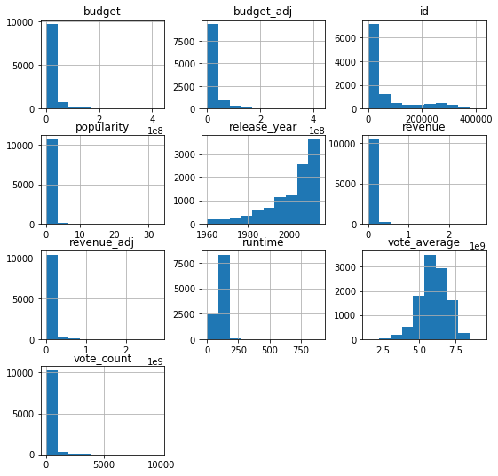

```python
df.hist(figsize=(9,9));
```

```python
df.describe()
```

|  | id | popularity | budget | revenue | runtime | vote_count | vote_average | release_year | budget_adj | revenue_adj |
| --- | --- | --- | --- | --- | --- | --- | --- | --- | --- | --- |
| count | 10866.000000 | 10866.000000 | 1.086600e+04 | 1.086600e+04 | 10866.000000 | 10866.000000 | 10866.000000 | 10866.000000 | 1.086600e+04 | 1.086600e+04 |
| mean | 66064.177434 | 0.646441 | 1.462570e+07 | 3.982332e+07 | 102.070863 | 217.389748 | 5.974922 | 2001.322658 | 1.755104e+07 | 5.136436e+07 |
| std | 92130.136561 | 1.000185 | 3.091321e+07 | 1.170035e+08 | 31.381405 | 575.619058 | 0.935142 | 12.812941 | 3.430616e+07 | 1.446325e+08 |
| min | 5.000000 | 0.000065 | 0.000000e+00 | 0.000000e+00 | 0.000000 | 10.000000 | 1.500000 | 1960.000000 | 0.000000e+00 | 0.000000e+00 |
| 25% | 10596.250000 | 0.207583 | 0.000000e+00 | 0.000000e+00 | 90.000000 | 17.000000 | 5.400000 | 1995.000000 | 0.000000e+00 | 0.000000e+00 |
| 50% | 20669.000000 | 0.383856 | 0.000000e+00 | 0.000000e+00 | 99.000000 | 38.000000 | 6.000000 | 2006.000000 | 0.000000e+00 | 0.000000e+00 |
| 75% | 75610.000000 | 0.713817 | 1.500000e+07 | 2.400000e+07 | 111.000000 | 145.750000 | 6.600000 | 2011.000000 | 2.085325e+07 | 3.369710e+07 |
| max | 417859.000000 | 32.985763 | 4.250000e+08 | 2.781506e+09 | 900.000000 | 9767.000000 | 9.200000 | 2015.000000 | 4.250000e+08 | 2.827124e+09 |

```python
df.info()
```

```
<class 'pandas.core.frame.DataFrame'>
RangeIndex: 10866 entries, 0 to 10865
Data columns (total 21 columns):
 #   Column                Non-Null Count  Dtype
---  ------                --------------  -----
 0   id                    10866 non-null  int64
 1   imdb_id               10856 non-null  object
 2   popularity            10866 non-null  float64
 3   budget                10866 non-null  int64
 4   revenue               10866 non-null  int64
 5   original_title        10866 non-null  object
 6   cast                  10790 non-null  object
 7   homepage              2936 non-null   object
 8   director              10822 non-null  object
 9   tagline               8042 non-null   object
 10  keywords              9373 non-null   object
 11  overview              10862 non-null  object
 12  runtime               10866 non-null  int64
 13  genres                10843 non-null  object
 14  production_companies  9836 non-null   object
 15  release_date          10866 non-null  object
 16  vote_count            10866 non-null  int64
 17  vote_average          10866 non-null  float64
 18  release_year          10866 non-null  int64
 19  budget_adj            10866 non-null  float64
 20  revenue_adj           10866 non-null  float64
dtypes: float64(4), int64(6), object(11)
memory usage: 1.7+ MB
```

### Data Cleaning (Fix some 0 value to NaN value, then drop those rows !)

### Oberservation from the data:

1. There is no currency unit mention in the data. So I consider the US Dollar Unit for the analysis
2. After the explore the data and watching at statistics summary, I got the 0 number rows in budget, revenue, and runtime. So I need to fix that by replacing 0 to NaN, then drop those rows.
3. Also, I find out unworthy columns for the analysis:- id, populairty, imdb_id, homepage, overview, tagline, budget_adj, revenue_adj, keywords, and release_date..etc Thus, I would like to drop those columns into the dataset.
4. Deleting the duplicate the data

```python
# After discussing the structure of the data and any problems that need to be cleaned,
# perform those cleaning steps in the second part of this section.
# first of drop the columns
df.drop(['id','popularity','imdb_id', 'homepage', 'tagline', 'keywords', 'overview', 'release_date', 'vote_count', 'budget_adj', 'revenue_adj'], axis=1, inplace=True)
```

```python
# confirm the columns have dropped
df.head(2)
```

|  | budget | revenue | original_title | cast | director | runtime | genres | production_companies | vote_average | release_year |
| --- | --- | --- | --- | --- | --- | --- | --- | --- | --- | --- |
| 0 | 150000000 | 1513528810 | Jurassic World | Chris Pratt\|Bryce Dallas Howard\|Irrfan Khan\|Vi... | Colin Trevorrow | 124 | Action\|Adventure\|Science Fiction\|Thriller | Universal Studios\|Amblin Entertainment\|Legenda... | 6.5 | 2015 |
| 1 | 150000000 | 378436354 | Mad Max: Fury Road | Tom Hardy\|Charlize Theron\|Hugh Keays-Byrne\|Nic... | George Miller | 120 | Action\|Adventure\|Science Fiction\|Thriller | Village Roadshow Pictures\|Kennedy Miller Produ... | 7.1 | 2015 |

```python
# return ths shape of dataframe
df.shape
```

```
(10866, 10)
```

```python
# check the how many null values
df.isnull().sum()
```

```
budget                     0
revenue                    0
original_title             0
cast                      76
director                  44
runtime                    0
genres                    23
production_companies    1030
vote_average               0
release_year               0
dtype: int64
```

```python
# Specically the watching the null data
df[df.isnull().any(axis=1)]
```

|  | budget | revenue | original_title | cast | director | runtime | genres | production_companies | vote_average | release_year |
| --- | --- | --- | --- | --- | --- | --- | --- | --- | --- | --- |
| 228 | 0 | 0 | Racing Extinction | Elon Musk\|Jane Goodall\|Louie Psihoyos\|Leilani ... | Louie Psihoyos | 90 | Adventure\|Documentary | NaN | 7.8 | 2015 |
| 259 | 0 | 0 | Crown for Christmas | Danica McKellar\|Rupert Penry-Jones\|Ellie Botte... | Alex Zamm | 84 | TV Movie | NaN | 7.6 | 2015 |
| 295 | 0 | 0 | 12 Gifts of Christmas | Katrina Law\|Donna Mills\|Aaron O'Connell\|Melani... | Peter Sullivan | 84 | Family\|TV Movie | NaN | 6.3 | 2015 |
| 298 | 0 | 0 | The Girl in the Photographs | Kal Penn\|Claudia Lee\|Kenny Wormald\|Toby Heming... | Nick Simon | 95 | Crime\|Horror\|Thriller | NaN | 4.7 | 2015 |
| 328 | 0 | 0 | Advantageous | Jacqueline Kim\|James Urbaniak\|Freya Adams\|Ken ... | Jennifer Phang | 92 | Science Fiction\|Drama\|Family | NaN | 6.4 | 2015 |
| ... | ... | ... | ... | ... | ... | ... | ... | ... | ... | ... |
| 10804 | 0 | 0 | Interiors | Diane Keaton\|Kristin Griffith\|Mary Beth Hurt\|R... | Woody Allen | 93 | Drama | NaN | 6.3 | 1978 |
| 10806 | 0 | 0 | Gates of Heaven | Lucille Billingsley\|Zella Graham\|Cal Harberts\|... | Errol Morris | 85 | Documentary | NaN | 5.9 | 1978 |
| 10816 | 0 | 0 | The Rutles: All You Need Is Cash | Eric Idle\|John Halsey\|Ricky Fataar\|Neil Innes\|... | Eric Idle\|Gary Weis | 76 | Comedy | NaN | 6.0 | 1978 |
| 10842 | 0 | 0 | Winnie the Pooh and the Honey Tree | Sterling Holloway\|Junius Matthews\|Sebastian Ca... | Wolfgang Reitherman | 25 | Animation\|Family | NaN | 7.9 | 1966 |
| 10853 | 0 | 0 | Alfie | Michael Caine\|Shelley Winters\|Millicent Martin... | Lewis Gilbert | 114 | Comedy\|Drama\|Romance | NaN | 6.2 | 1966 |

1093 rows × 10 columns

Above result showing **NaN** values in the rows. Also **0** values that should replace with **NaN**, then drop the all rows.

```python
# replace 0 to NaN and drop all NaN values.
df.replace(0, np.nan, inplace=True)
```

```python
# confirm all 0 values to NaN replace successfully. i,e there is no 0 values.
df.isin([0]).any().any()
```

```
False
```

```python
# drop all NaN values
df.dropna(inplace=True)
```

```python
# Check any null.
df.isnull().sum().any()
```

```
False
```

```python
df.head(2)
```

|  | budget | revenue | original_title | cast | director | runtime | genres | production_companies | vote_average | release_year |
| --- | --- | --- | --- | --- | --- | --- | --- | --- | --- | --- |
| 0 | 150000000.0 | 1.513529e+09 | Jurassic World | Chris Pratt\|Bryce Dallas Howard\|Irrfan Khan\|Vi... | Colin Trevorrow | 124.0 | Action\|Adventure\|Science Fiction\|Thriller | Universal Studios\|Amblin Entertainment\|Legenda... | 6.5 | 2015 |
| 1 | 150000000.0 | 3.784364e+08 | Mad Max: Fury Road | Tom Hardy\|Charlize Theron\|Hugh Keays-Byrne\|Nic... | George Miller | 120.0 | Action\|Adventure\|Science Fiction\|Thriller | Village Roadshow Pictures\|Kennedy Miller Produ... | 7.1 | 2015 |

Since watching at the above result, one thing notice *budget* and *revenue* columns look like messy in decimal. So, I would like change datatype into the *int64.*

```python
# converting float to int
df = df.astype({'budget': 'int64', 'revenue': 'int64'})
```

As below you can see the change the columns name of **budget and revenue** into the *budget*(US*dollar)* and *revenue*(US*dollar)*.

```python
# Also, rename both column as appropriate labels.
df.rename(columns = {'budget': 'budget_(US_dollar)', 'revenue':'revenue_(US_dollar)'}, inplace=True)
```

```python
# confirm the changes of the datatypes and columns label
df.dtypes
```

```
budget_(US_dollar)        int64
revenue_(US_dollar)       int64
original_title           object
cast                     object
director                 object
runtime                 float64
genres                   object
production_companies     object
vote_average            float64
release_year              int64
dtype: object
```

```python
# checking the duplicate rows
df.duplicated().sum()
```

```
1
```

```python
# drop the duplicate row
df.drop_duplicates(inplace=True)
```

```python
# check the confirmation
df.duplicated().sum()
```

```
0
```

```python
# shape of the dataframe
df.shape
```

```
(3805, 10)
```

### Spliting the columns by the string "|" in row

> After the close analysis I feel that I can explore the data through the split **"|"** data of genres, cast, and director, then combine them seperately into the original dataframe. Afterwards, I drop orginal column that which we don't need for the analysis.

```python
# spliting and checking the column
df['director'].str.split('|', expand=True).rename(columns = lambda x: "director_"+str(x+1))
```

|  | director_1 | director_2 | director_3 | director_4 | director_5 | director_6 | director_7 | director_8 | director_9 | director_10 | director_11 | director_12 |
| --- | --- | --- | --- | --- | --- | --- | --- | --- | --- | --- | --- | --- |
| 0 | Colin Trevorrow | None | None | None | None | None | None | None | None | None | None | None |
| 1 | George Miller | None | None | None | None | None | None | None | None | None | None | None |
| 2 | Robert Schwentke | None | None | None | None | None | None | None | None | None | None | None |
| 3 | J.J. Abrams | None | None | None | None | None | None | None | None | None | None | None |
| 4 | James Wan | None | None | None | None | None | None | None | None | None | None | None |
| ... | ... | ... | ... | ... | ... | ... | ... | ... | ... | ... | ... | ... |
| 10822 | Mike Nichols | None | None | None | None | None | None | None | None | None | None | None |
| 10828 | Alfred Hitchcock | None | None | None | None | None | None | None | None | None | None | None |
| 10829 | Howard Hawks | None | None | None | None | None | None | None | None | None | None | None |
| 10835 | Robert Wise | None | None | None | None | None | None | None | None | None | None | None |
| 10848 | Richard Fleischer | None | None | None | None | None | None | None | None | None | None | None |

3805 rows × 12 columns

Above result show 12 directors column that could be outliers. let's checking by following:-

```python
# I am looking how much string long.
# df.director.map(len).max()
# df.director.map(lambda x: len(x)).max()
df.director.map(len).max()
```

```
169
```

Above I found director string which is more than 100 length of the string which roughly consist of 8 to 12 director seperated by **"|".** This is too much for our analysis and it make cumbersome. I delete those rows as considering a **outlier.**

```python
# Specifically watching and confirmation
df[df.director.str.len() > 100]
```

|  | budget_(US_dollar) | revenue_(US_dollar) | original_title | cast | director | runtime | genres | production_companies | vote_average | release_year |
| --- | --- | --- | --- | --- | --- | --- | --- | --- | --- | --- |
| 1458 | 14700000 | 8049666 | New York, I Love You | Natalie Portman\|Shia LaBeouf\|Orlando Bloom\|Chr... | Natalie Portman\|Fatih Akin\|Mira Nair\|Allen Hug... | 103.0 | Drama\|Comedy\|Romance | Vivendi Entertainment | 5.6 | 2009 |
| 2477 | 80000000 | 90874570 | Fantasia 2000 | Steve Martin\|Quincy Jones\|Bette Midler\|James E... | Paul Brizzi\|Hendel Butoy\|Francis Glebas\|Eric G... | 74.0 | Music\|Animation\|Family\|Fantasy | Walt Disney Pictures\|Walt Disney Television An... | 6.9 | 1999 |
| 5535 | 6000000 | 32438988 | Movie 43 | Dennis Quaid\|Greg Kinnear\|Common\|Charlie Saxto... | Steven Brill\|Elizabeth Banks\|Steve Carr\|Rusty ... | 90.0 | Comedy | Greenestreet Films\|Relativity Media\|Virgin Pro... | 4.4 | 2013 |

```python
# drop by the index
df.drop([1458, 2477, 5535], inplace=True)
```

```python
# let's confirm
df[df.director.str.len() > 100]
```

|  | budget_(US_dollar) | revenue_(US_dollar) | original_title | cast | director | runtime | genres | production_companies | vote_average | release_year |
| --- | --- | --- | --- | --- | --- | --- | --- | --- | --- | --- |

```python
# Split Genre, Cast, and Director column
# Using the lambda function for assigning the column name dynamically
df_genre = df['genres'].str.split('|', expand=True).rename(columns = lambda x: "genre_"+str(x+1))
df_cast = df['cast'].str.split('|', expand=True).rename(columns = lambda x: "cast_"+str(x+1))
df_director = df['director'].str.split('|', expand=True).rename(columns = lambda x: "director_"+str(x+1))
```

```python
# Join into the original DataFrame
df = df.join([df_genre, df_cast, df_director])
```

```python
# Drop following feature columns
df.drop(['genres', 'cast', 'director'], axis=1, inplace=True)
```

```python
# check the column and datatypes
df.dtypes
```

```
budget_(US_dollar)        int64
revenue_(US_dollar)       int64
original_title           object
runtime                 float64
production_companies     object
vote_average            float64
release_year              int64
genre_1                  object
genre_2                  object
genre_3                  object
genre_4                  object
genre_5                  object
cast_1                   object
cast_2                   object
cast_3                   object
cast_4                   object
cast_5                   object
director_1               object
director_2               object
director_3               object
director_4               object
director_5               object
director_6               object
dtype: object
```

```python
# reset the index after the cleaning up the data
df.reset_index(drop=True, inplace=True)
```

```python
# Everything seems to be perfect by index.
df.tail()
```

|  | budget_(US_dollar) | revenue_(US_dollar) | original_title | runtime | production_companies | vote_average | release_year | genre_1 | genre_2 | genre_3 | ... | cast_2 | cast_3 | cast_4 | cast_5 | director_1 | director_2 | director_3 | director_4 | director_5 | director_6 |
| --- | --- | --- | --- | --- | --- | --- | --- | --- | --- | --- | --- | --- | --- | --- | --- | --- | --- | --- | --- | --- | --- |
| 3797 | 7500000 | 33736689 | Who's Afraid of Virginia Woolf? | 131.0 | Chenault Productions | 7.5 | 1966 | Drama | None | None | ... | Richard Burton | George Segal | Sandy Dennis | Agnes Flanagan | Mike Nichols | None | None | None | None | None |
| 3798 | 3000000 | 13000000 | Torn Curtain | 128.0 | Universal Pictures | 6.3 | 1966 | Mystery | Thriller | None | ... | Julie Andrews | Lila Kedrova | HansjÃ¶rg Felmy | Tamara Toumanova | Alfred Hitchcock | None | None | None | None | None |
| 3799 | 4653000 | 6000000 | El Dorado | 120.0 | Paramount Pictures\|Laurel Productions | 6.9 | 1966 | Action | Western | None | ... | Robert Mitchum | James Caan | Charlene Holt | Paul Fix | Howard Hawks | None | None | None | None | None |
| 3800 | 12000000 | 20000000 | The Sand Pebbles | 182.0 | Twentieth Century Fox Film Corporation\|Solar P... | 7.0 | 1966 | Action | Adventure | Drama | ... | Richard Attenborough | Richard Crenna | Candice Bergen | Emmanuelle Arsan | Robert Wise | None | None | None | None | None |
| 3801 | 5115000 | 12000000 | Fantastic Voyage | 100.0 | Twentieth Century Fox Film Corporation | 6.7 | 1966 | Adventure | Science Fiction | None | ... | Raquel Welch | Edmond O'Brien | Donald Pleasence | Arthur O'Connell | Richard Fleischer | None | None | None | None | None |

5 rows × 23 columns

Just finished the clearning the data and let's move forward to the exploration

## Exploratory Data Analysis

> **Tip**: Now that you've trimmed and cleaned your data, you're ready to move on to exploration. Compute statistics and create visualizations with the goal of addressing the research questions that you posed in the Introduction section. It is recommended that you be systematic with your approach. Look at one variable at a time, and then follow it up by looking at relationships between variables.

### Research Question 1 (Which moives has highest and lowest profit?)

> I imagine most of the our analysis in the term of the movie profit. To make further data analysis easy, I insert new columns as **_movie*profit*** on the basis on Movie revenue - budget.

> **movie_profit = revenue - budget**

```python
# Adding the new columns "profit"
df.insert(2, 'movie_profit', df['revenue_(US_dollar)'] - df['budget_(US_dollar)'])
```

```python
# confirm
df.head(2)
```

|  | budget_(US_dollar) | revenue_(US_dollar) | movie_profit | original_title | runtime | production_companies | vote_average | release_year | genre_1 | genre_2 | ... | cast_2 | cast_3 | cast_4 | cast_5 | director_1 | director_2 | director_3 | director_4 | director_5 | director_6 |
| --- | --- | --- | --- | --- | --- | --- | --- | --- | --- | --- | --- | --- | --- | --- | --- | --- | --- | --- | --- | --- | --- |
| 0 | 150000000 | 1513528810 | 1363528810 | Jurassic World | 124.0 | Universal Studios\|Amblin Entertainment\|Legenda... | 6.5 | 2015 | Action | Adventure | ... | Bryce Dallas Howard | Irrfan Khan | Vincent D'Onofrio | Nick Robinson | Colin Trevorrow | None | None | None | None | None |
| 1 | 150000000 | 378436354 | 228436354 | Mad Max: Fury Road | 120.0 | Village Roadshow Pictures\|Kennedy Miller Produ... | 7.1 | 2015 | Action | Adventure | ... | Charlize Theron | Hugh Keays-Byrne | Nicholas Hoult | Josh Helman | George Miller | None | None | None | None | None |

2 rows × 24 columns

```python
# I define the fucntion that retrun maximum and minimum value column in term of movie_profit
def max_min(column):

    # obtain max value of column
    df_max = df.iloc[df[column].idxmax()]

    # obtain min value of column
    df_min = df.iloc[df[column].idxmin()]

    # concatenate both information
    df_info = pd.concat([df_max, df_min], axis=1)

    # return the result
    return df_info
```

```python
max_min('movie_profit')
```

|  | 344 | 677 |
| --- | --- | --- |
| budget_(US_dollar) | 237000000 | 425000000 |
| revenue_(US_dollar) | 2781505847 | 11087569 |
| movie_profit | 2544505847 | -413912431 |
| original_title | Avatar | The Warrior's Way |
| runtime | 162 | 100 |
| production_companies | Ingenious Film Partners\|Twentieth Century Fox ... | Boram Entertainment Inc. |
| vote_average | 7.1 | 6.4 |
| release_year | 2009 | 2010 |
| genre_1 | Action | Adventure |
| genre_2 | Adventure | Fantasy |
| genre_3 | Fantasy | Action |
| genre_4 | Science Fiction | Western |
| genre_5 | None | Thriller |
| cast_1 | Sam Worthington | Kate Bosworth |
| cast_2 | Zoe Saldana | Jang Dong-gun |
| cast_3 | Sigourney Weaver | Geoffrey Rush |
| cast_4 | Stephen Lang | Danny Huston |
| cast_5 | Michelle Rodriguez | Ti Lung |
| director_1 | James Cameron | Sngmoo Lee |
| director_2 | None | None |
| director_3 | None | None |
| director_4 | None | None |
| director_5 | None | None |
| director_6 | None | None |

As you can see, Avatar is highest profit **2544505847** as 344 index and whereas The Warrior's Way is lowest profit **-413912431.** as 677 index

### Research Question 2 (Best movie runtime in term of profit?)

```python
# Using groupby clause getting best runtime in term of profit
best_avg_runtime = df.groupby('runtime')['movie_profit'].sum().sort_values(ascending=False)
```

```python
# Best movie in the runtime in term of movie profit
best_avg_runtime.head()
```

```
runtime
130.0    7636942726
115.0    7531073476
124.0    6998868730
136.0    6697827329
93.0     6394360070
Name: movie_profit, dtype: int64
```

The best rutime is *130.0 minutes* long movie that makes most profit.

### Research Question 3 (Which is the popular movie genres in term of movie profit?)

#### Logic:

> I imagine like above result **genre_1, genre_2, genre_3, genre_4, genre_5** each hold muliple genres, then calculating movie profit of sum for the indivisual columns. Finally, I combine them altogether and calcuate the sum of their respective genre which is provide best movie genre in term movie profit.

Apply groupby function as sum summary on feature columns, then converted into the dataframe

```python
# Define the function
def column_group(col_name):

    # store the result in variable as form of dataframe
    col_return = pd.DataFrame(df.groupby(col_name)['movie_profit'].sum())

    # return result with ascending order
    return col_return.sort_values(by='movie_profit', ascending=False)
```

I define the function and reduce redundacy of the code. You can see above comments.

Also, define the **compute function** which is combine the all dataframe, then return *best value* in term of profit

```python
# defination of function
def compute(columns_pd):

    # combine the datafram
    df_concat = pd.concat(columns_pd, ignore_index=False)

    # reset the index
    df_concat.reset_index(inplace=True)

    # rename the appropriate column
    df_concat.rename(columns={'index': 'name'}, inplace=True)

    # Use group function to get summary of each genre
    df_best = df_concat.groupby('name').sum()

    # Sort the value by descending order
    df_best_sort = df_best.sort_values(by='movie_profit', ascending=False)


    # return the final output
    return df_best_sort
```

```python
# Invoke the function of column_group and store result into the variables
df_gen_1 = column_group('genre_1')
df_gen_2 = column_group('genre_2')
df_gen_3 = column_group('genre_3')
df_gen_4 = column_group('genre_4')
df_gen_5 = column_group('genre_5')
```

```python
# it is look like
df_gen_5.head()
```

| genre_5 | movie_profit |
| --- | --- |
| Fantasy | 4053612731 |
| Family | 3167454008 |
| Thriller | 2551749316 |
| Science Fiction | 2275633561 |
| Action | 2215392200 |

```python
# Invoke the computer fucntion and store the result
best_genre = compute([df_gen_1,df_gen_2,df_gen_3,df_gen_4,df_gen_5])
```

```python
# series_genre = best_genre.iloc[:,0]
# Showing the result top 5
best_genre.head()
```

| name | movie_profit |
| --- | --- |
| Adventure | 111124901066 |
| Action | 108592213161 |
| Comedy | 87173831855 |
| Drama | 81228550009 |
| Thriller | 72735918406 |

**Adventure** is the best genre which has made highest profit, then Action, Comedy, and Drama as subsequent genres

Let's used the Graphical analysis with bar plot

[figure not shown]

```python
# Creating the horizintal bar graph because seems to be approporiate for view
best_genre.sort_values(by='movie_profit', ascending=True, inplace=True)
best_genre.plot.barh(figsize=(18, 10), rot=15, color='purple', fontsize = '12')

# title and label
plt.title('popular movie genres in term of movie profit', fontsize = '16')
plt.ylabel('Genres', fontsize='16', color = 'black')
plt.xlabel('Amount in one hundred millions Dollar', fontsize='16', color = 'black')
plt.show(block=True)
```

### Research Question 4 (Which is the successful actor/actress in term of movie profit?)

```python
# Invoke column_group function for each cast features
df_cast_1 = column_group('cast_1')
df_cast_2 = column_group('cast_2')
df_cast_3 = column_group('cast_3')
df_cast_4 = column_group('cast_4')
df_cast_5 = column_group('cast_5')
```

```python
# Calling the compute function and store result into the variable
best_actor = compute([df_cast_1,df_cast_2,df_cast_3,df_cast_4,df_cast_5])
```

```python
best_actor.head()
```

| name | movie_profit |
| --- | --- |
| Harrison Ford | 6713284728 |
| Emma Watson | 6666245597 |
| Daniel Radcliffe | 6511036755 |
| Tom Cruise | 6431203020 |
| Rupert Grint | 6408638290 |

The most sucessful actor is **Harrison Ford** who make highest profit in the movies, then Emma Watson in the second place.

### Research Question 5 (Which is the Best director in term of movie profit?)

```python
# Invoke column_group function for each director columns
df_director_1 = column_group('director_1')
df_director_2 = column_group('director_2')
df_director_3 = column_group('director_3')
df_director_4 = column_group('director_4')
df_director_5 = column_group('director_5')
df_director_6 = column_group('director_6')
```

```python
# Calling the compute function and store result into the variable
best_director = compute([df_director_1,df_director_2,df_director_3,df_director_4,df_director_5,df_director_6])
```

```python
best_director.head()
```

| name | movie_profit |
| --- | --- |
| Steven Spielberg | 7486514691 |
| Peter Jackson | 5197244659 |
| James Cameron | 5081994863 |
| Michael Bay | 3557208171 |
| David Yates | 3379295625 |

The best director is **Steven Spielberg** with *7486514691* profit

### Research Question 6 (Which is the highest and lowest budget of movie genre?)

```python
# Calculate the alternative ways without function on the basis of the budget
df_genbudget_1 = pd.DataFrame(df.groupby('genre_1')['budget_(US_dollar)'].sum())
df_genbudget_2 = pd.DataFrame(df.groupby('genre_2')['budget_(US_dollar)'].sum())
df_genbudget_3 = pd.DataFrame(df.groupby('genre_3')['budget_(US_dollar)'].sum())
df_genbudget_4 = pd.DataFrame(df.groupby('genre_4')['budget_(US_dollar)'].sum())
df_genbudget_5 = pd.DataFrame(df.groupby('genre_5')['budget_(US_dollar)'].sum())
```

```python
# defination of function
def compute_budget(columns_pd):

    # combine the datafram
    df_concat = pd.concat(columns_pd, ignore_index=False)

    # reset the index
    df_concat.reset_index(inplace=True)

    # rename the appropriate column
    df_concat.rename(columns={'index': 'genre'}, inplace=True)

    # Use group function to get summary of each genre
    df_best = df_concat.groupby('genre').sum()

    # Sort the value by descending order
    df_best_sort = df_best.sort_values(by='budget_(US_dollar)', ascending=False)

    # reset the index
    df_best_sort.reset_index(inplace=True)

    # store the result highest and lowest
    highest = df_best_sort.iloc[df_best_sort['budget_(US_dollar)'].idxmax()]
    lowest = df_best_sort.iloc[df_best_sort['budget_(US_dollar)'].idxmin()]

    # combine
    final_concat = pd.concat([highest, lowest], axis=1)

    # return the final output
    return final_concat
```

```python
gen_budget = compute_budget([df_genbudget_1, df_genbudget_2, df_genbudget_3, df_genbudget_4, df_genbudget_5])
```

```python
gen_budget
```

|  | 0 | 19 |
| --- | --- | --- |
| genre | Action | TV Movie |
| budget_(US_dollar) | 61197499268 | 5000000 |

The movie maker would like to spend dollar on the **Action** genre while *TV Movies* genre has lowest.

### Reaseach Question 7 (Compare the movie genre produce in year 2000 and 2015?)

```python
# Define the fucntion
def combine_year_2000(col_name):

    # count genre in year 2000 and store result
    gen_2000 = pd.DataFrame(df[df.release_year == 2000].groupby(col_name)['release_year'].count())

    # return result
    return gen_2000

# Similary
def combine_year_2015(col_name):

    # count genre in year 2015 and store result
    gen_2015 = pd.DataFrame(df[df.release_year == 2015].groupby(col_name)['release_year'].count())

    # return result
    return gen_2015
```

```python
# Year 2000 dataframe
gen1_2000 = combine_year_2000('genre_1')
gen2_2000 = combine_year_2000('genre_2')
gen3_2000 = combine_year_2000('genre_3')
gen4_2000 = combine_year_2000('genre_4')
gen5_2000 = combine_year_2000('genre_5')

# Year 2015 dataframe
gen1_2015 = combine_year_2015('genre_1')
gen2_2015 = combine_year_2015('genre_2')
gen3_2015 = combine_year_2015('genre_3')
gen4_2015 = combine_year_2015('genre_4')
gen5_2015 = combine_year_2015('genre_5')
```

```python
# check and confirm
gen1_2000
```

| genre_1 | release_year |
| --- | --- |
| Action | 20 |
| Adventure | 7 |
| Animation | 4 |
| Comedy | 22 |
| Crime | 6 |
| Drama | 22 |
| Family | 1 |
| Fantasy | 4 |
| Horror | 6 |
| Mystery | 2 |
| Romance | 1 |
| Science Fiction | 3 |
| Thriller | 6 |

```python
# defination of function
def compute_year(columns_pd):

    # combine the datafram
    df_concat = pd.concat(columns_pd, ignore_index=False)

    # reset the index
    df_concat.reset_index(inplace=True)

    # rename the appropriate column
    df_concat.rename(columns={'index': 'name'}, inplace=True)

    # Use group function to get summary of each genre
    df_best = df_concat.groupby('name').sum()

    # Sort the value by descending order
    df_best_sort = df_best.sort_values(by='release_year', ascending=False)


    # return the final output
    return df_best_sort
```

```python
# Invoke compute_year function and rename the columns
gen_2000_data = compute_year([gen1_2000,gen2_2000,gen3_2000,gen4_2000,gen5_2000])
gen_2000_data.rename(columns={'release_year':'release_year_(2000)'}, inplace=True)

# Invoke compute_year function and rename the columns
gen_2015_data = compute_year([gen1_2015,gen2_2015,gen3_2015,gen4_2015,gen5_2015])
gen_2015_data.rename(columns={'release_year':'release_year_(2015)'}, inplace=True)
```

```python
# Replace NaN value to 0
comp_2000_2015 = pd.concat([gen_2000_data, gen_2015_data], axis=1).replace(np.nan, 0)
```

```python
# Because of Nan it's converted into the flot. I should fix this datatype into int64
comp_2000_2015= comp_2000_2015.astype({'release_year_(2015)': 'int64'})
```

```python
# Final result of 2000 and 2015 genre production
comp_2000_2015
```

|  | release_year_(2000) | release_year_(2015) |
| --- | --- | --- |
| Drama | 44 | 81 |
| Comedy | 42 | 52 |
| Thriller | 32 | 47 |
| Action | 29 | 37 |
| Adventure | 19 | 34 |
| Crime | 17 | 24 |
| Romance | 16 | 18 |
| Science Fiction | 14 | 22 |
| Family | 12 | 13 |
| Fantasy | 10 | 13 |
| Mystery | 9 | 13 |
| Horror | 8 | 17 |
| Animation | 7 | 9 |
| Music | 5 | 9 |
| War | 3 | 5 |
| History | 2 | 5 |
| Foreign | 1 | 0 |
| Western | 1 | 2 |

Now I would like to compared through bar garph than table.

```python
# store each column of above result into the seperate vairable
data_2000 = comp_2000_2015['release_year_(2000)']
data_2015 = comp_2000_2015['release_year_(2015)']
```

```python
# np.arange just creating array
ind = np.arange(len(data_2000))    # the x locations for the groups
width = 0.35       # the width of the bars
```

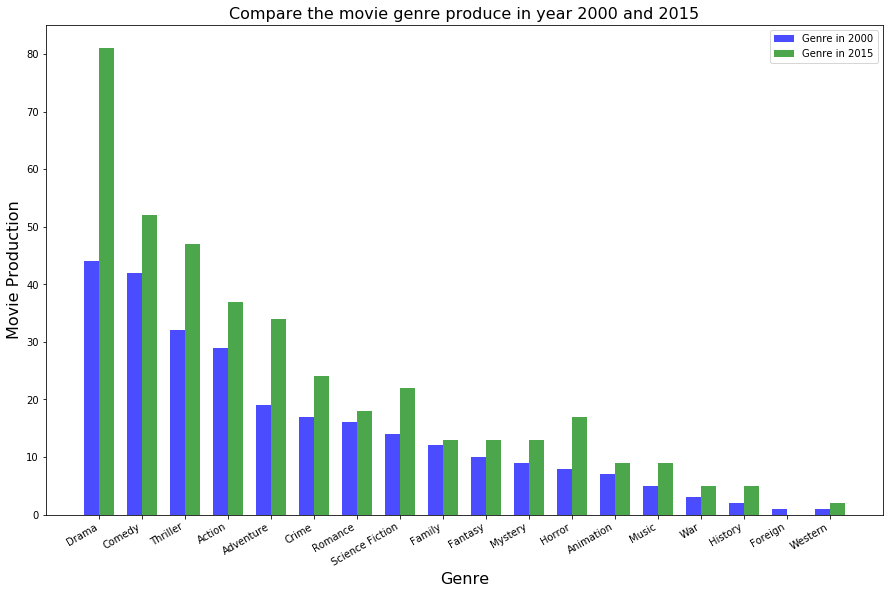

```python
# Creating the bar plot for 2000 and 2015
bar_2000 = plt.bar(ind, comp_2000_2015['release_year_(2000)'], width, color='b', alpha=.7, label='Genre in 2000')
bar_2015 = plt.bar(ind + width, comp_2000_2015['release_year_(2015)'], width, color='g', alpha=.7, label='Genre in 2015')


# Title and Labels
plt.xlabel('Genre', fontsize = '16', color = 'black')
plt.ylabel('Movie Production', fontsize = '16', color = 'black')
plt.title('Compare the movie genre produce in year 2000 and 2015', fontsize = '16', color = 'black')
locations = ind + width / 2  # xtick locations
labels = gen_2000_data.index # xtick labels
plt.xticks(locations, labels)

# Adjust the figsize
plt.rcParams["figure.figsize"] = (15,10)

# legend
plt.legend()

# plt.show()
# Due to overlapping x labels I used autoformat for x labels instead of plt.show
plt.gcf().autofmt_xdate();
```

### Reaseach Question 8 (Does the higher average movie vote prdict a higher movie profit?)

```python
# arrage the data and store result into the variable
voting = pd.DataFrame(df.groupby('vote_average')['movie_profit'].mean().sort_values(ascending=False))
```

```python
# reset the index
voting.reset_index(inplace=True)
```

```python
# np.round(voting['movie_profit'], decimals=3)
# voting = np.round(voting, decimals=1)
# Display the result
voting
```

|  | vote_average | movie_profit |
| --- | --- | --- |
| 0 | 8.1 | 3.362431e+08 |
| 1 | 7.9 | 3.071137e+08 |
| 2 | 8.3 | 2.390664e+08 |
| 3 | 7.7 | 1.941848e+08 |
| 4 | 8.0 | 1.923533e+08 |
| 5 | 7.8 | 1.901513e+08 |
| 6 | 7.5 | 1.901165e+08 |
| 7 | 7.4 | 1.875883e+08 |
| 8 | 7.6 | 1.546138e+08 |
| 9 | 7.3 | 1.491223e+08 |
| 10 | 7.1 | 1.164866e+08 |
| 11 | 7.2 | 1.126892e+08 |
| 12 | 7.0 | 1.039577e+08 |
| 13 | 6.9 | 9.522367e+07 |
| 14 | 6.4 | 8.884258e+07 |
| 15 | 6.8 | 8.358968e+07 |
| 16 | 6.5 | 8.290462e+07 |
| 17 | 6.6 | 8.255311e+07 |
| 18 | 6.1 | 7.504468e+07 |
| 19 | 6.3 | 6.703372e+07 |
| 20 | 6.2 | 5.920976e+07 |
| 21 | 5.6 | 5.866836e+07 |
| 22 | 5.8 | 5.772132e+07 |
| 23 | 6.0 | 5.711277e+07 |
| 24 | 6.7 | 5.633095e+07 |
| 25 | 5.9 | 5.009680e+07 |
| 26 | 5.5 | 4.821145e+07 |
| 27 | 5.7 | 4.099069e+07 |
| 28 | 3.4 | 3.684187e+07 |
| 29 | 5.3 | 2.882613e+07 |
| 30 | 5.1 | 2.382564e+07 |
| 31 | 5.4 | 2.360499e+07 |
| 32 | 5.2 | 1.995168e+07 |
| 33 | 5.0 | 1.883315e+07 |
| 34 | 3.6 | 1.668139e+07 |
| 35 | 4.2 | 1.595562e+07 |
| 36 | 4.7 | 1.587238e+07 |
| 37 | 8.2 | 1.069309e+07 |
| 38 | 3.9 | 7.586951e+06 |
| 39 | 4.4 | 7.498313e+06 |
| 40 | 4.6 | 7.452268e+06 |
| 41 | 3.7 | 7.022091e+06 |
| 42 | 4.8 | 5.083436e+06 |
| 43 | 4.9 | 4.816227e+06 |
| 44 | 4.5 | 4.032079e+06 |
| 45 | 8.4 | 3.560196e+06 |
| 46 | 4.3 | 3.300728e+06 |
| 47 | 4.1 | -3.492320e+06 |
| 48 | 3.8 | -6.029859e+06 |
| 49 | 3.5 | -8.317513e+06 |
| 50 | 3.3 | -1.252685e+07 |
| 51 | 4.0 | -1.477917e+07 |
| 52 | 2.2 | -6.492629e+07 |

Above result show, voting average does affect the movie profit. You can see *movie voting range 8 and 7 at the top of the movie profit*. Here I mainly concerned about **quality than quantity**. For instace, ten movie has better outcome (average movie profit) than 50 movies.

### Reaseach Question 9 (how does amount of movie production change since 1960 to 2015?)

```python
# Same as earlier above using the groupby function
movie_production = pd.DataFrame(df.groupby('release_year')['original_title'].count())

# reset the index
movie_production.reset_index(inplace=True)

# rename the column
movie_production.rename(columns = {'original_title':'movies'}, inplace=True)
```

```python
# Display the result
movie_production
```

|  | release_year | movies |
| --- | --- | --- |
| 0 | 1960 | 5 |
| 1 | 1961 | 10 |
| 2 | 1962 | 7 |
| 3 | 1963 | 6 |
| 4 | 1964 | 7 |
| 5 | 1965 | 5 |
| 6 | 1966 | 5 |
| 7 | 1967 | 13 |
| 8 | 1968 | 9 |
| 9 | 1969 | 4 |
| 10 | 1970 | 11 |
| 11 | 1971 | 13 |
| 12 | 1972 | 8 |
| 13 | 1973 | 12 |
| 14 | 1974 | 13 |
| 15 | 1975 | 9 |
| 16 | 1976 | 15 |
| 17 | 1977 | 19 |
| 18 | 1978 | 17 |
| 19 | 1979 | 16 |
| 20 | 1980 | 23 |
| 21 | 1981 | 30 |
| 22 | 1982 | 26 |
| 23 | 1983 | 31 |
| 24 | 1984 | 42 |
| 25 | 1985 | 41 |
| 26 | 1986 | 47 |
| 27 | 1987 | 46 |
| 28 | 1988 | 56 |
| 29 | 1989 | 51 |
| 30 | 1990 | 52 |
| 31 | 1991 | 50 |
| 32 | 1992 | 53 |
| 33 | 1993 | 72 |
| 34 | 1994 | 61 |
| 35 | 1995 | 79 |
| 36 | 1996 | 84 |
| 37 | 1997 | 90 |
| 38 | 1998 | 90 |
| 39 | 1999 | 115 |
| 40 | 2000 | 104 |
| 41 | 2001 | 118 |
| 42 | 2002 | 125 |
| 43 | 2003 | 121 |
| 44 | 2004 | 142 |
| 45 | 2005 | 159 |
| 46 | 2006 | 168 |
| 47 | 2007 | 159 |
| 48 | 2008 | 161 |
| 49 | 2009 | 169 |
| 50 | 2010 | 177 |
| 51 | 2011 | 196 |
| 52 | 2012 | 157 |
| 53 | 2013 | 178 |
| 54 | 2014 | 165 |
| 55 | 2015 | 160 |

Result showing earlier production obiviously very low because of lack of resources and technologies. However, if you take glance from 21st centuary, you see the up and down variation in the production movies that changing over time year by year.

Let's depict with line graph how production change in visual senes

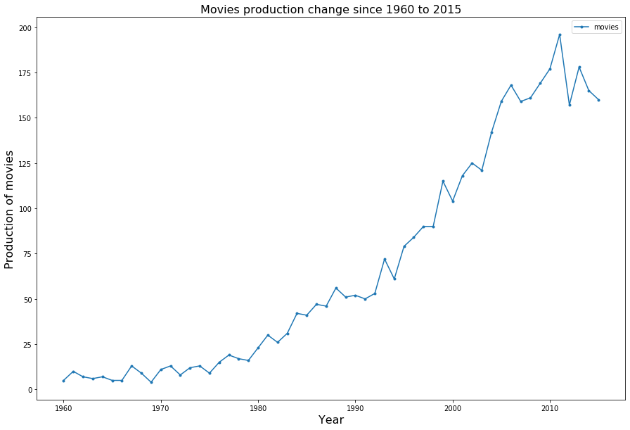

```python
# Let's draw the Line plot
movie_production.plot(kind = 'line', style = '.-', x='release_year', y='movies', figsize=(15,10))

# title and label
plt.title('Movies production change since 1960 to 2015', fontsize = 16, color = 'black')
plt.ylabel('Production of movies', fontsize = 16, color = 'black')
plt.xlabel('Year', fontsize = 16, color = 'black')
plt.legend();
```

## Conclusions

**Limitations:** Above analysis has given nice sense about movie profit. However, we have some remarks that make this analysis vague and addressed major flaws. We just droped the abundant rows that value had 0 and NaN data without replacing with appropirate value by the applying advance statical and machine learning tehcnique can affect overall analysis. Also, We haven't given exact currency. Afterwards, we used our assumption to choose the USD dollar for all the movie profit. It is possible there so many countries make profit in the different currency. So without knowing correct knowledge we cannot assume result is correct.